# IODS-final

### Analysis

**Linear regression**  
This statistical test is testing how well the target value ($y$) corresponds to the explanatory variables ($x_1, x_2, x_3, ...$), if we assume that there is a linear regression between the variables, so that $y = \alpha + \beta_1x_1 + \beta_2x_2 + \beta_3x_3 + ... + \epsilon$, where $\epsilon$ is assumed to be a normally distributed error variable with a mean of 0.

##### **Grades as target**

```r
summary(lm(alc$G3 ~ alc$famrel + alc$alc_use))
```

```
##
## Call:
## lm(formula = alc$G3 ~ alc$famrel + alc$alc_use)
##
## Residuals:
##      Min       1Q   Median       3Q      Max
## -11.4110  -1.8158   0.1842   2.3172   6.3348
##
## Coefficients:
##             Estimate Std. Error t value Pr(>|t|)
## (Intercept)  11.8251     0.8550  13.831  < 2e-16 ***
## alc$famrel    0.1506     0.1867   0.807  0.42022
## alc$alc_use  -0.5083     0.1717  -2.961  0.00326 **
## ---
## Signif. codes:  0 '***' 0.001 '**' 0.01 '*' 0.05 '.' 0.1 ' ' 1
##
## Residual standard error: 3.275 on 379 degrees of freedom
## Multiple R-squared:  0.02608,    Adjusted R-squared:  0.02094
## F-statistic: 5.074 on 2 and 379 DF,  p-value: 0.00669
```

Here we have a summary of the linear regression model, where $y$ = G3 $x_1$ = famrel and $x_2$ = alc_use. Our results are as follows: $\beta_1$ = 0.1506 and $\beta_2$ = -0.5083. We have two null hyphothesis - one that family relationships don’t explain the grades and one that nor does the usage of alcohol ($\beta_{1,2} = 0$). For the first hypothesis we get a p-value of 0.42, which doesn’t lead to rejection of the null hypothesis. On the other hand, for the later hypothesis we get a p-value of 0.003, which tells that with a significance level of 0.05 we can reject the null hypothesis quite confidently. Let’s draw a plot to see this result:

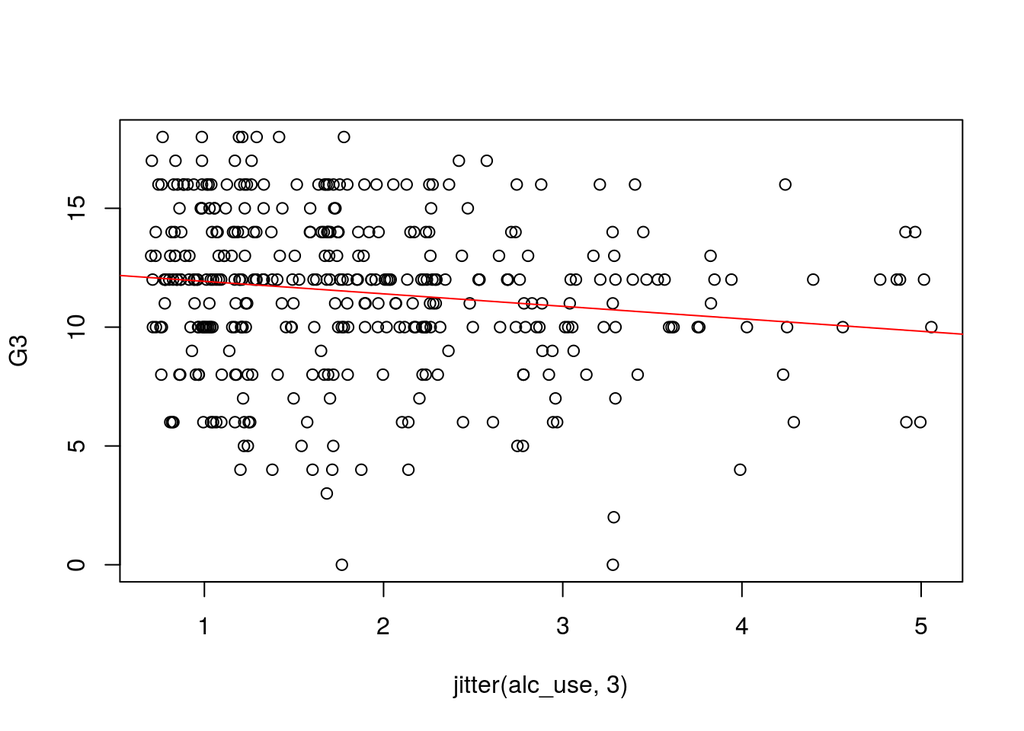

```r
plot(G3 ~ jitter(alc_use,3), data = alc)
abline(lm(G3 ~ alc_use, data = alc), col = "red")
```

##### **Usage of alcohol as target**

Next let’s have a look at the hypothesis that family relationships explain the usage of alcohol.

```r
summary(lm(alc_use ~ famrel,data = alc))
```

```
##
## Call:
## lm(formula = alc_use ~ famrel, data = alc)
##
## Residuals:
##     Min      1Q  Median      3Q     Max
## -1.2757 -0.7757 -0.2487  0.6195  3.2513
##
## Coefficients:
##             Estimate Std. Error t value Pr(>|t|)
## (Intercept)  2.40746    0.22369  10.762   <2e-16 ***
## famrel      -0.13175    0.05537  -2.379   0.0178 *
## ---
## Signif. codes:  0 '***' 0.001 '**' 0.01 '*' 0.05 '.' 0.1 ' ' 1
##
## Residual standard error: 0.9789 on 380 degrees of freedom
## Multiple R-squared:  0.01468,    Adjusted R-squared:  0.01209
## F-statistic: 5.661 on 1 and 380 DF,  p-value: 0.01784
```

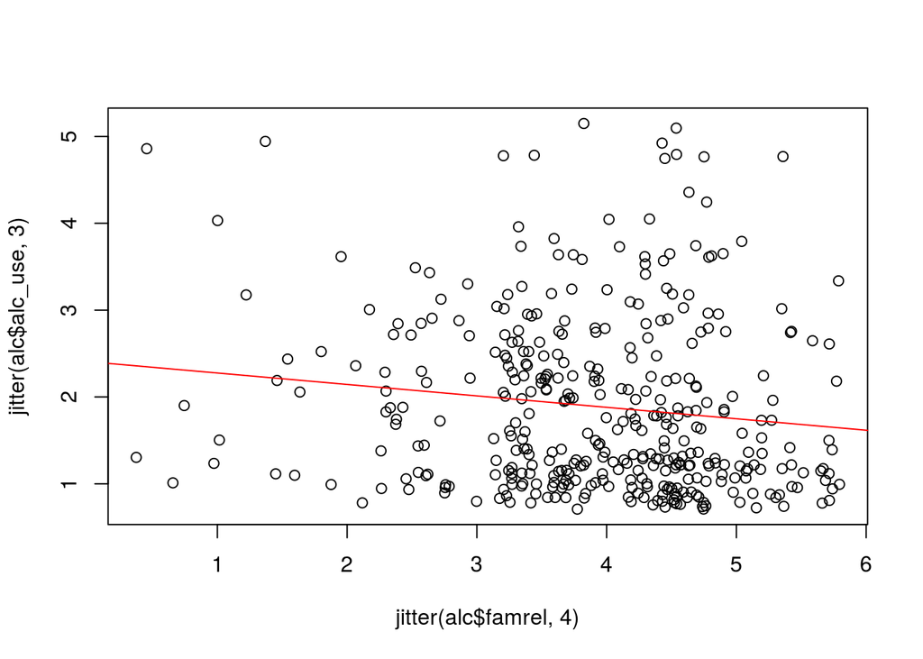

```r
plot(jitter(alc$alc_use,3) ~ jitter(alc$famrel,4))
abline(lm(alc_use ~ famrel, data = alc), col = "red")
```

Looks like we can reject this null hypothesis and conclude that better family relationships tend to decrease the usage of alcohol.

### Conclusions and discussion

Our results are as following:

- family relationships doesn’t have effect on grades
- greater usage of alcohol leads to worse grades
- better family relationships imply smaller usage of alcohol